# Capstone progress report 2

**Interpreting Logistic Regression Coefficients**

```
Top 10 Positive Coefficients (Strong predictors of seeking treatment):

family_history            0.697066
care_options              0.341690
self_employed             0.241358
age                       0.163244
tech_role                 0.130416
coworker_comfort          0.122585
tech_company              0.073037
mental_health_benefits    0.065771
work_country              0.065506
country                   0.060032
dtype: float64

Top 10 Negative Coefficients (Strong predictors of NOT seeking treatment):

gender                  -0.236106
equal_mental_physical   -0.179874
supervisor_comfort      -0.066970
resources_provided      -0.055674
leave_difficulty        -0.053249
remote_work              0.002135
company_size             0.032655
employer_discussed       0.055953
country                  0.060032
work_country             0.065506
dtype: float64
```

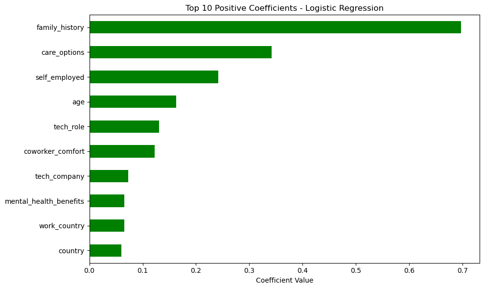

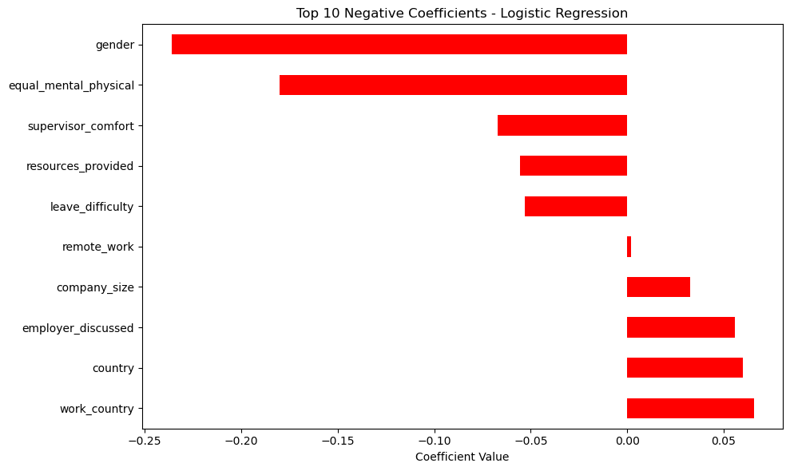

```python
import matplotlib.pyplot as plt

# Creating a Series from logistic regression coefficients
logreg_coefficients = pd.Series(logreg.coef_[0], index=X.columns)

# Top 10 features that positively influence seeking treatment
top_positive = logreg_coefficients.nlargest(10)
print("Top 10 Positive Coefficients (Strong predictors of seeking treatment):\n")
print(top_positive, "\n")

# Top 10 features that negatively influence seeking treatment
top_negative = logreg_coefficients.nsmallest(10)
print("Top 10 Negative Coefficients (Strong predictors of NOT seeking treatment):\n")
print(top_negative, "\n")

# Plotting after printing
# Positive
plt.figure(figsize=(10, 6))
top_positive.plot(kind='barh', color='green')
plt.title("Top 10 Positive Coefficients - Logistic Regression")
plt.xlabel("Coefficient Value")
plt.gca().invert_yaxis()
plt.tight_layout()
plt.show()

# Negative
plt.figure(figsize=(10, 6))
top_negative.plot(kind='barh', color='red')
plt.title("Top 10 Negative Coefficients - Logistic Regression")
plt.xlabel("Coefficient Value")
plt.gca().invert_yaxis()
plt.tight_layout()
plt.show()
```

**Top Positive Influences (Seeking Treatment)** The following features had the strongest positive coefficients, meaning they increased the likelihood of seeking mental health treatment: Family History (0.69): Individuals with a family history of mental illness were significantly more likely to seek treatment themselves. This aligns with established behavioral trends, where personal exposure to mental health issues increases awareness and help-seeking behavior. Knowledge of Care Options (0.34): Awareness of available care options had a strong influence, highlighting the importance of employer communication and education. Self-Employment (0.24): Interestingly, self-employed individuals were more likely to seek treatment, possibly due to having more flexible schedules or recognizing the importance of self-care. Age (0.16): Older participants were slightly more likely to seek help, perhaps reflecting greater maturity or reduced stigma. Tech Role & Tech Company (0.13 & 0.07): Working in technical roles or companies showed positive association, suggesting those immersed in tech environments may be more open or aware of mental health services. Coworker Comfort & Mental Health Benefits (~0.12 & 0.07): Feeling comfortable discussing mental health with coworkers, and having benefits, naturally supported help-seeking behavior.

**Summary** The model confirms that awareness, openness, and personal history are key drivers for seeking help, while perceived stigma, limited trust, or passive environments are barriers. These insights guide practical changes like: Enhancing awareness campaigns Encouraging open communication with supervisors Promoting transparency about leave and treatment options